# Lab6

Spicy Bois: Logan, Tyler, Trent, Joe, Jack

10/1/2019

# What Factors Lead to On-time Arrivals in Denver?

**Why are they Important:** This question is important, because knowing the factors that lead to delay’s will allow the DEN to make changes in order to reduce these delay’s. This will increase custermore satifaction and lead to allowing more flights to come in and out of DEN. This will generate more profits, and money is important to any company.

## Team’s Studies

### Plot 1

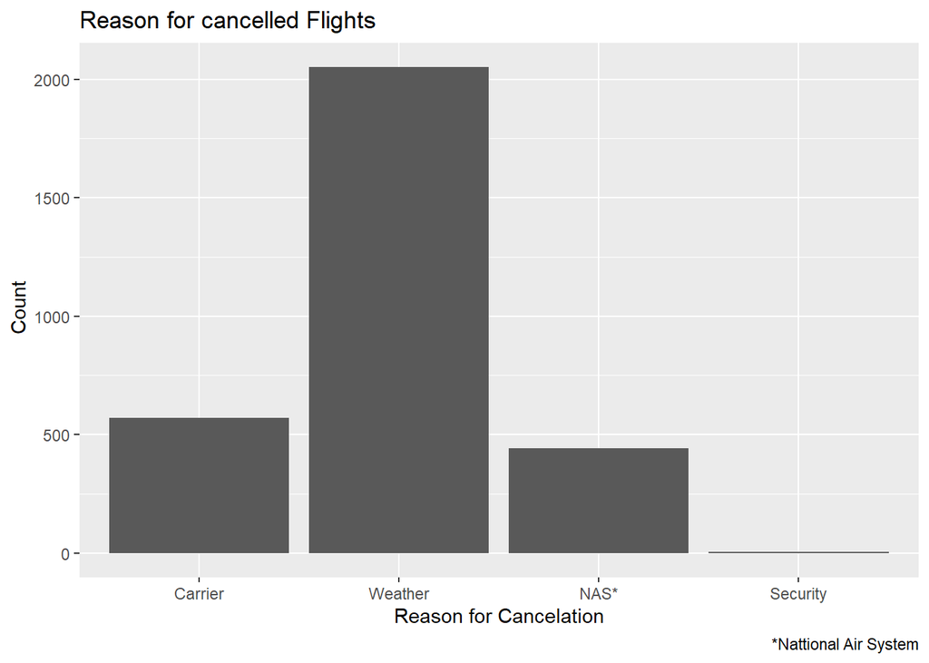

```r
DENCanceled <- DENflights %>% filter(!is.na(CANCELLATION_CODE))

ggplot(data = DENCanceled) + geom_bar(mapping = aes(x = CANCELLATION_CODE)) +
  scale_x_discrete(labels = c("Carrier", "Weather", "NAS*", "Security")) +
  labs(title = "Reason for cancelled Flights", x = "Reason for Cancelation", y =" Count",  caption = "*Nattional Air System")
```

## Individual Studies

### Probability Flights will be Delayed based on Weather (Tyler)

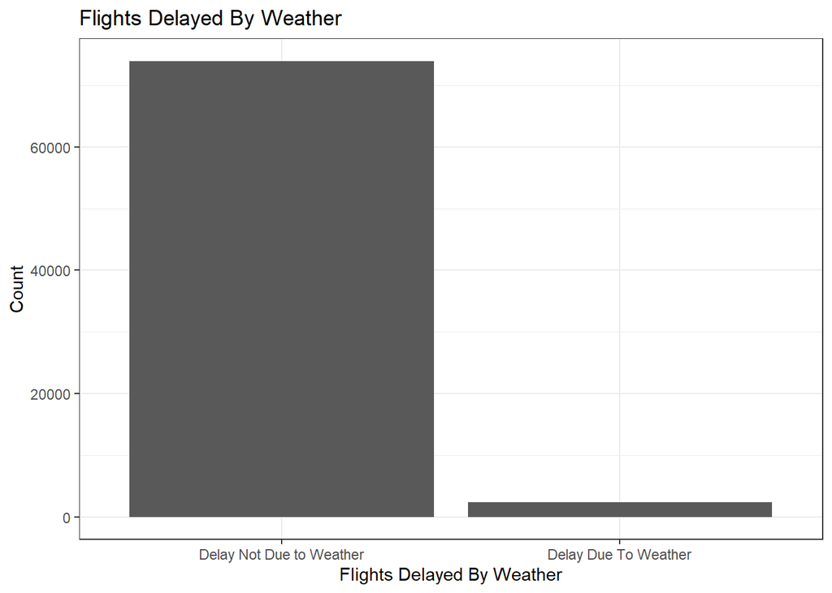

```r
DENdelay <- DENflights %>% filter(ARR_DELAY >= 15) %>% mutate(DELAY_WEATHER = (WEATHER_DELAY >= 15))

ggplot(data = DENdelay) +  geom_bar(mapping = aes(x = DELAY_WEATHER)) +
  labs(title = "Flights Delayed By Weather", x = "Flights Delayed By Weather", y = "Count") +
  theme_bw() +
  scale_x_discrete(labels = c("Delay Not Due to Weather", "Delay Due To Weather"))
```

```r
total <- DENdelay %>% group_by(DELAY_WEATHER) %>% summarise(count = n()) %>% mutate(count = sum(count)) %>% filter(DELAY_WEATHER == FALSE)

truth <- DENdelay %>% group_by(DELAY_WEATHER) %>% summarise(count = n()) %>% filter(DELAY_WEATHER == TRUE)

truth$count/total$count * 100
```

```
## [1] 3.125942
```

As shown by the graph the weather delay does not affect flights being delayed to or from denver. Only 3.12% of delayed flights end up being delayed by the weather. There is a big difference in the amount of flights delayed by weather and the ones not delayed by weather. This clearly shows that weather is not a main cause of the flights that get delayed.

###How does Air Time affect if a flights delayed (Tyler)

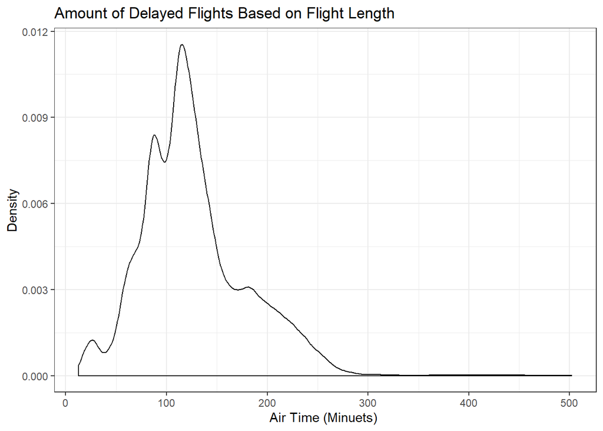

```r
airDelay <- DENflights %>% filter(ARR_DELAY >= 15)

ggplot(data = airDelay) + geom_density(mapping = aes(x = AIR_TIME)) +
  theme_bw() +
  labs(title = "Amount of Delayed Flights Based on Flight Length", x = "Air Time (Minuets) ", y = "Density")
```

```r
shortAir <- airDelay %>% filter(AIR_TIME <= 180) %>% group_by(CARRIER) %>% summarise(count = n()) %>% mutate(count = sum(count)) %>% filter(CARRIER == 'UA')

totalAir <- airDelay %>% group_by(CARRIER) %>% summarise(count = n()) %>% mutate(count = sum(count)) %>% filter(CARRIER == 'UA')

shortAir$count/totalAir$count *100
```

```
## [1] 83.94712
```

As shows by the graph a lot of flights under 3 hours(a short flight) tend to be delayed more often then long flights. Of all flights that got delayed, 84% of them were a short flight. The longer the flight became, the less they would be delayed. A possible confounding variable could be the amount of flights that are short against the amount of flights that are long. There are more short flights per day then there are long flights.

### Probabilities Flights will be Delayed Based on Season (Trent)

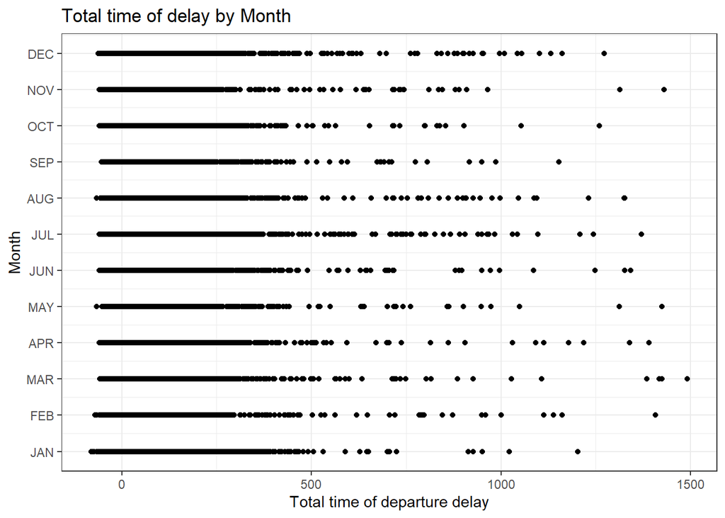

```r
ggplot(DENflights) + geom_point(aes(ARR_DELAY, MONTH)) +
  theme_bw() +
  scale_y_continuous(breaks = c(1, 2, 3, 4, 5, 6, 7, 8, 9, 10, 11, 12),
                     labels = c("JAN", "FEB", "MAR", "APR", "MAY", "JUN", "JUL", "AUG",
                                "SEP", "OCT", "NOV", "DEC"))+
  labs(title = 'Total time of delay by Month',
       x='Total time of departure delay',
       y='Month')
```

```r
DENflights <- DENflights %>% mutate(ARR_DELAY_LOG = (ARR_DELAY >= 15 ))

SPRdelay <- DENflights %>% filter(MONTH == "3" | MONTH == "4" | MONTH == "5") %>% group_by(ARR_DELAY_LOG) %>% summarise(count = n()) %>% mutate(total = sum(count))
SPRdelay
```

```
## # A tibble: 3 x 3
##   ARR_DELAY_LOG count  total
##   <lgl>         <int>  <int>
## 1 FALSE         91315 110994
## 2 TRUE          18674 110994
## 3 NA             1005 110994
```

```r
SUMdelay <- DENflights %>% filter(MONTH == "6" | MONTH == "7" | MONTH == "8") %>% group_by(ARR_DELAY_LOG) %>% summarise(count = n()) %>% mutate(total = sum(count))
SUMdelay
```

```
## # A tibble: 3 x 3
##   ARR_DELAY_LOG count  total
##   <lgl>         <int>  <int>
## 1 FALSE         97527 122890
## 2 TRUE          24166 122890
## 3 NA             1197 122890
```

```r
FALLdelay <- DENflights %>% filter(MONTH == "9" | MONTH == "10" | MONTH == "11") %>% group_by(ARR_DELAY_LOG) %>% summarise(count = n()) %>% mutate(total = sum(count))
FALLdelay
```

```
## # A tibble: 3 x 3
##   ARR_DELAY_LOG count  total
##   <lgl>         <int>  <int>
## 1 FALSE         97218 111276
## 2 TRUE          13434 111276
## 3 NA              624 111276
```

```r
WINdelay <- DENflights %>% filter(MONTH == "12" | MONTH == "1" | MONTH == "2") %>% group_by(ARR_DELAY_LOG) %>% summarise(count = n()) %>% mutate(total = sum(count))
WINdelay
```

```
## # A tibble: 3 x 3
##   ARR_DELAY_LOG count  total
##   <lgl>         <int>  <int>
## 1 FALSE         80039 101239
## 2 TRUE          20055 101239
## 3 NA             1145 101239
```

Time of year can be a major factor that can effect whether or not a flight may be delayed, due to factors such as weather, school holidays, and major holidays such Christmas. As show in the graph above, there is not a significant amount of discrepancy between the amounts of delayed flights per month, but there are still some apparent and relevant trends. The months with a larger amount of delays are July and December, unsurprising due to the higher number of vacations that happen in the summer, and the large air traffic that comes with the Christmas season. If we break the year down in seasons, there is roughly a 16.8% chance to be delayed during the spring months (March, April, May), a 19.7% chance of being delayed during the summer months (June, July, and August), a 12.1% chance of being delayed during the fall months (September, October, November), and a 19.8% of being delayed during the winter months (December, January, February).

### Probabilities Flights will be Delayed Based on Carrier (Trent)

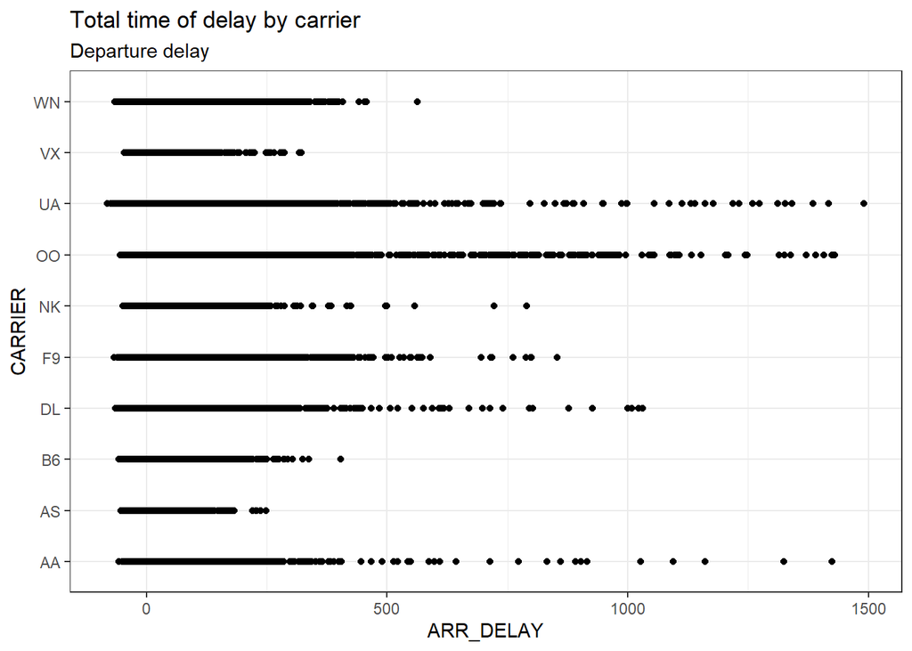

```r
ggplot(DENflights) + geom_point(aes(ARR_DELAY, CARRIER)) +
  theme_bw() +
  labs(title = 'Total time of delay by carrier',
       subtitle = 'Departure delay',
       xlab='Total time of departure delay',
       ylab='Airline Carrier')
```

```r
UAdelay <- DENflights %>% filter(CARRIER == "UA") %>% group_by(ARR_DELAY_LOG) %>% summarise(count = n()) %>% mutate(total = sum(count))
UAdelay
```

```
## # A tibble: 3 x 3
##   ARR_DELAY_LOG  count  total
##   <lgl>          <int>  <int>
## 1 FALSE         106987 123779
## 2 TRUE           16037 123779
## 3 NA               755 123779
```

```r
OOdelay <- DENflights %>% filter(CARRIER == "OO") %>% group_by(ARR_DELAY_LOG) %>% summarise(count = n()) %>% mutate(total = sum(count))
OOdelay
```

```
## # A tibble: 3 x 3
##   ARR_DELAY_LOG count total
##   <lgl>         <int> <int>
## 1 FALSE         70786 85711
## 2 TRUE          13735 85711
## 3 NA             1190 85711
```

```r
VXdelay <- DENflights %>% filter(CARRIER == "VX") %>% group_by(ARR_DELAY_LOG) %>% summarise(count = n()) %>% mutate(total = sum(count))
VXdelay
```

```
## # A tibble: 3 x 3
##   ARR_DELAY_LOG count total
##   <lgl>         <int> <int>
## 1 FALSE          1506  2067
## 2 TRUE            530  2067
## 3 NA               31  2067
```

```r
ASdelay <- DENflights %>% filter(CARRIER == "AS") %>% group_by(ARR_DELAY_LOG) %>% summarise(count = n()) %>% mutate(total = sum(count))
ASdelay
```

```
## # A tibble: 3 x 3
##   ARR_DELAY_LOG count total
##   <lgl>         <int> <int>
## 1 FALSE          2791  3387
## 2 TRUE            572  3387
## 3 NA               24  3387
```

Which airline consumers choose to fly on can also be a major factor that can affect if a flight is delayed. From plotting the amount and scale of each carrier’s arrival delay, it would seem from the graph that the two airlines with the most and longest delays are UA (United Airlines) and OO (Skywest), and the two airlines with the least delays are VX (Virgin Airlines) and AS (Alaska Airlines). When calculating the probabilities, there is roughly a 12.9% chance of being delayed flying with United, and a 16.0% chance of being delayed on Skywest, the two biggest culprits for tardy flights. However, the probability of being delayed when flying with Virgin is roughly 25.6%, and a 16.9% of being delayed on Alaska. So even though Alaska and Virgin appear to be the airlines with the smaller and least amount of delays, they have a significantly smaller amount of total flights when compared to larger airlines like United and Skywest. This is due to the larger airlines being prone to more extreme outliers and different outcomes, resulting in a larger, more misleading spread of data.

### Probabilities Flight Landing in DEN will be Delayed Based on Origin. (LOGAN)

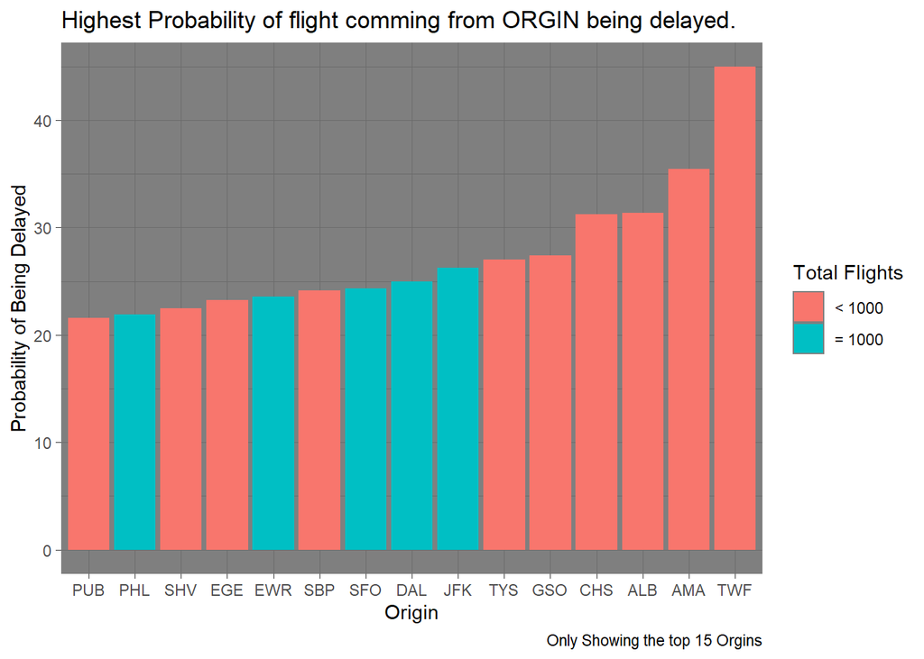

```r
DEN_ORGIN_Delay <- DENflights %>% filter(DEST == "DEN", !is.na(ARR_DELAY)) %>%
  group_by(ORIGIN) %>%
  summarise(min_delay = min(ARR_DELAY),
            max_delay = max(ARR_DELAY),
            avg_delay = mean(ARR_DELAY),
            sum_delay = sum(ARR_DELAY >= 15),
            sum_flights = n(),
            prop_delay = sum_delay / sum_flights *100) %>%
  arrange(desc(prop_delay)) %>%
  slice(1:15)

DEN_ORGIN_Delay$ORIGIN <- factor(DEN_ORGIN_Delay$ORIGIN, levels = DEN_ORGIN_Delay$ORIGIN[order(DEN_ORGIN_Delay$prop_delay)])

ggplot(DEN_ORGIN_Delay, aes(x = ORIGIN, y = prop_delay, fill = (sum_flights >= 1000))) +
  geom_col() +
  theme_dark() +
  labs(title = "Highest Probability of flight comming from ORGIN being delayed.", x = "Origin", y = "Probability of Being Delayed", caption = "Only Showing the top 15 Orgins") +
  scale_fill_discrete(name = "Total Flights", labels = c("< 1000", "≥ 1000"))
```

**Findings:** Based on the chart above, where the fight is comming from has a big part on wether the flight is delayed. It is seen that that TWF has the highest probability of beeing delayed, with 45% chance that a flight from TWF is going to be delayed. Of corse TWF does not have alot of flights from TWF (only 20), where as JFK (#7), DAL (#8), and SFO (#9) has alot more flight from them. These means, that although TWF and AMA have a high probality of being delayed, it might be better to look at airports such as JFK, DAL, and SFO, first since they have a lot more traffic going from them, which means they will have a lot more total flights that going to be delayed.

### Probabilities Flight Leaving from DEN will be Delayed Based on DEST. (LOGAN)

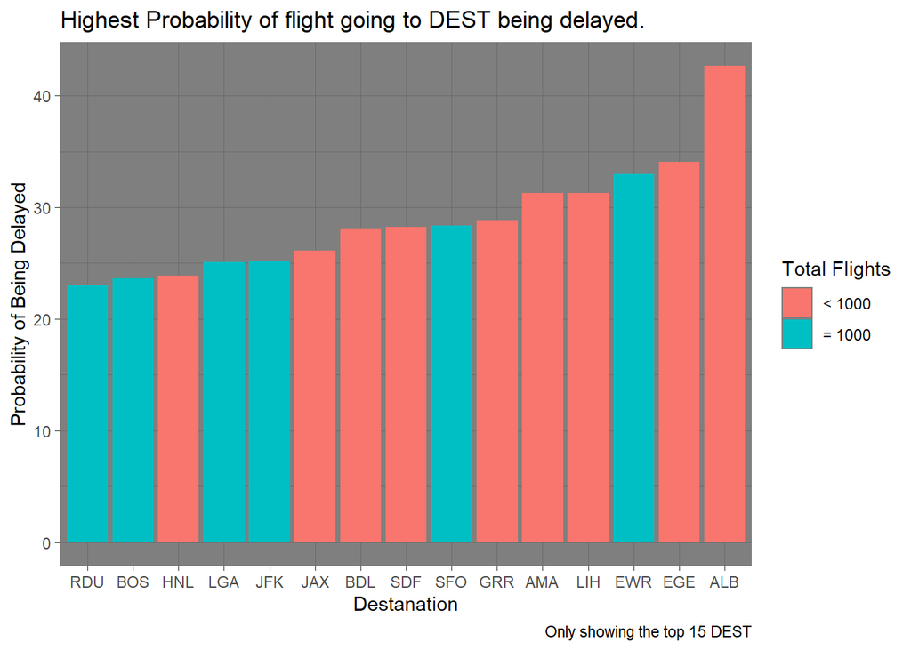

```r
DEST_DEN_Delay <- DENflights %>%
  filter(ORIGIN == "DEN", !is.na(DEP_DELAY)) %>%
  group_by(DEST) %>%
  summarise(min_delay = min(DEP_DELAY),
            max_delay = max(DEP_DELAY),
            avg_delay = mean(DEP_DELAY),
            sum_delay = sum(DEP_DELAY >= 15),
            sum_flights = n(),
            prop_delay = sum_delay / sum_flights *100) %>%
  arrange(desc(prop_delay)) %>%
  slice(1:15)

DEST_DEN_Delay$DEST <- factor(DEST_DEN_Delay$DEST, levels = DEST_DEN_Delay$DEST[order(DEST_DEN_Delay$prop_delay)])

ggplot(DEST_DEN_Delay, aes(x = DEST, y = prop_delay, fill = (sum_flights >= 1000))) +
  theme_dark() +
  geom_col() +
  labs(title = "Highest Probability of flight going to DEST being delayed.", x = "Destanation", y = "Probability of Being Delayed", caption = "Only showing the top 15 DEST") +
  scale_fill_discrete(name = "Total Flights", labels = c("< 1000", "≥ 1000"))
```

**Findings:** Based on the chart above, where the fight is going to has a big part on wether the flight is delayed. It is seen that that ALB has the highest probability of beeing delayed, with 42% chance that a flight going to ALB is going to be delayed. Of couse it is also seen that ALB, does not have alot of flights going to it. Destanations, such as EWR (#3) and SFO (#7) do have a lot of flights going to it, yet still have a high chance of being delayed. These types of airports will have a more signifanct impact to DEN.

### Probability Flights will be Arriving late based on National Air System delays (Jack)

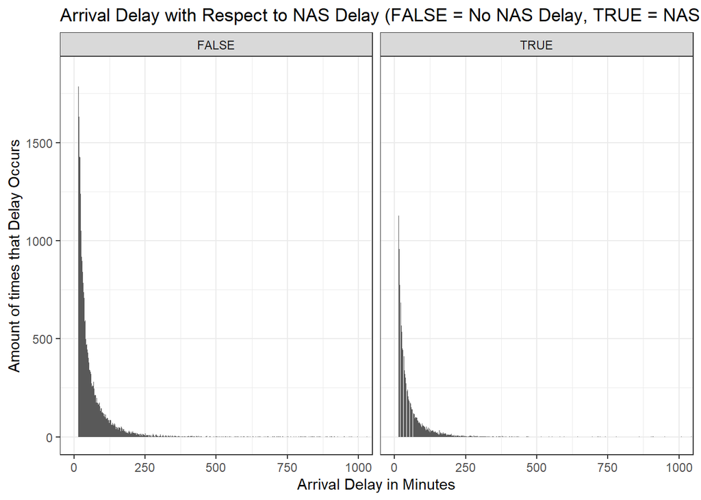

```r
delay <- DENflights %>% filter(ARR_DELAY >= 15) %>% mutate(DELAY_NAS = (NAS_DELAY >= 15))
NAS <- DENflights %>% filter(ARR_DELAY >= 15) %>% filter(NAS_DELAY >= 15)
ggplot(data = delay) +  geom_bar(mapping = aes(x = ARR_DELAY)) + facet_wrap(~DELAY_NAS) + theme_bw() + coord_cartesian(xlim =c(0, 1000)) +
  labs(title = 'Arrival Delay with Respect to NAS Delay (FALSE = No NAS Delay, TRUE = NAS Delay',
       x = 'Arrival Delay in Minutes',
       y = 'Amount of times that Delay Occurs')
```

```r
76329/446399 #probability flight was delayed on arrival
```

```
## [1] 0.1709883
```

```r
25199/446399 #probability flight was delayed on arrival due to NAS delays
```

```
## [1] 0.0564495
```

```r
25199/76329 #probability a delayed flight was due to a NAS delay
```

```
## [1] 0.3301366
```

National Air System delays don’t happen very often, but they are still a factor determining whether a flight will arrive on time. The graph above shows all arrival delays in groups, the first being the flight did not have an NAS delay, and the second being that the flight did have an NAS delay. It seems as if the graphs had a very similar trend with the amount of times the time of delay was counted and whether or not it had an NAS delay. The probability that a delayed arrival was caused by the NAS was about 33.01%. This means that for all delayed arriving flights, there’s about a 1 in 3 chance that it was caused by the NAS.

### Probability Departing Flight will be Delayed due to Late Aircraft Delays (Jack)

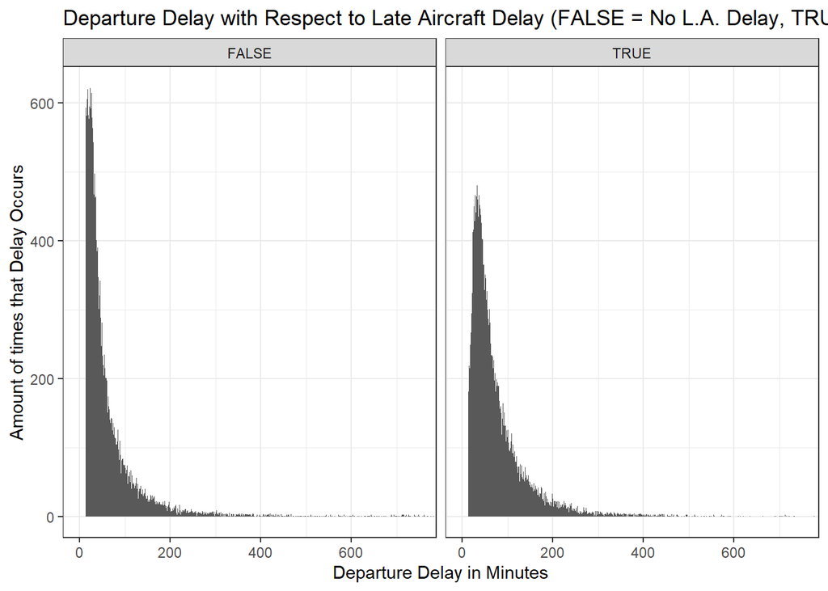

```r
delay <- DENflights %>% filter(DEP_DELAY >= 15) %>%  filter(!is.na(LATE_AIRCRAFT_DELAY)) %>% mutate(LATE_DELAY = (LATE_AIRCRAFT_DELAY >= 15))
LATE <- DENflights %>% filter(DEP_DELAY >= 15) %>% filter(LATE_AIRCRAFT_DELAY >= 15)
ggplot(data = delay) +  geom_bar(mapping = aes(x = DEP_DELAY)) + facet_wrap(~LATE_DELAY) + theme_bw() + coord_cartesian(xlim =c(0, 750)) +
  labs(title = 'Departure Delay with Respect to Late Aircraft Delay (FALSE = No L.A. Delay, TRUE = L.A. Delay',
       x = 'Departure Delay in Minutes',
       y = 'Amount of times that Delay Occurs')
```

```r
58426/446399 #probability flight had delayed departure
```

```
## [1] 0.1308829
```

```r
30628/446399 #probability flight departed late due to late aircraft delays
```

```
## [1] 0.06861126
```

```r
30628/58426 #probability a delayed flight was due to a late aircraft delay
```

```
## [1] 0.5242187
```

The graphs above show the all departure delays. The one on the left is all departure delays that were not caused by a late aircraft, and the one on the right are the delays that were. Just by looking at the graph, it seems as if the amount of times the delay time in minutes occured were very similar between the two graphs. I calculated the probability that given the flight was delayed, what was the chance that occurred due to a late aircraft delay. Turns out, more than half the flights that had a flight depart late was caused by a late aircraft delay. This means that over 1 in 2 flights that departed late were due to the fact that a plane had departed late as well.

##Is there a connection between the taxi times of a flight and whether the flight was late to arrive or not? (JOE)

```r
library(tidyverse)
COflights <- read_csv("https://files.osf.io/v1/resources/3z5as4pej8/providers/osfstorage/5a8ca28f57103100104584db")
library(tidyverse)
denfly <- COflights%>% filter(DEST == 'DEN') %>% filter(!is.na(ARR_TIME))
taxinum <- denfly %>% filter(ARR_DELAY > 15) %>% count()
taxidenom <- denfly %>% filter (TAXI_OUT > 30) %>% filter(ARR_DELAY > 15) %>% count()
taxipercent <- taxinum/taxidenom
taxipercent
```

```
##         n
## 1 6.21496
```

```r
library(tidyverse)
taxonum <- denfly %>% filter(ARR_DELAY > 15) %>% count()
taxodenom <- denfly %>% filter (TAXI_IN > 30) %>% filter(ARR_DELAY > 15) %>% count()
taxopercent <- taxonum/taxodenom
taxopercent
```

```
##          n
## 1 35.03862
```

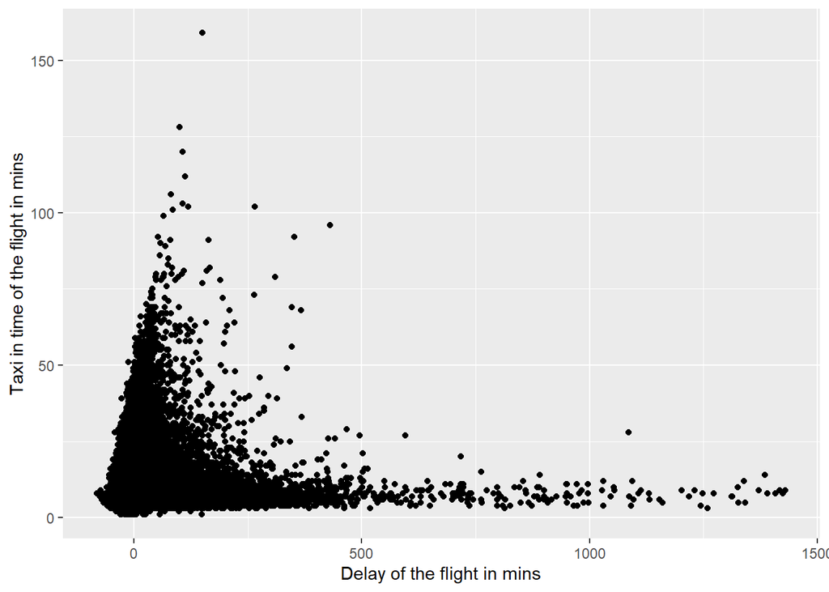

```r
ggplot(data = denfly)+
  geom_point(
    mapping = aes(x = ARR_DELAY, y = TAXI_IN)) +
  xlab("Delay of the flight in mins")+
  ylab("Taxi in time of the flight in mins")
```

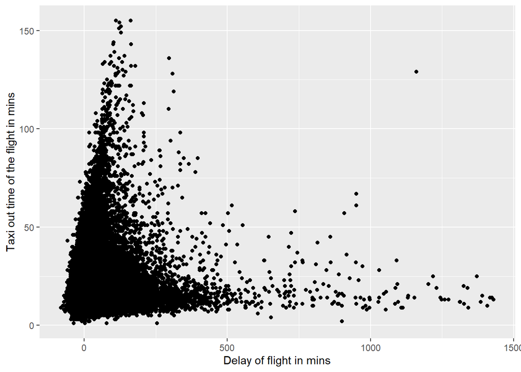

```r
ggplot(data = denfly)+
  geom_point(
    mapping = aes(x = ARR_DELAY, y = TAXI_OUT)) +
  xlab("Delay of flight in mins") +
  ylab("Taxi out time of the flight in mins")
```

##Graphs that answer our essential question (Trent and Logan)

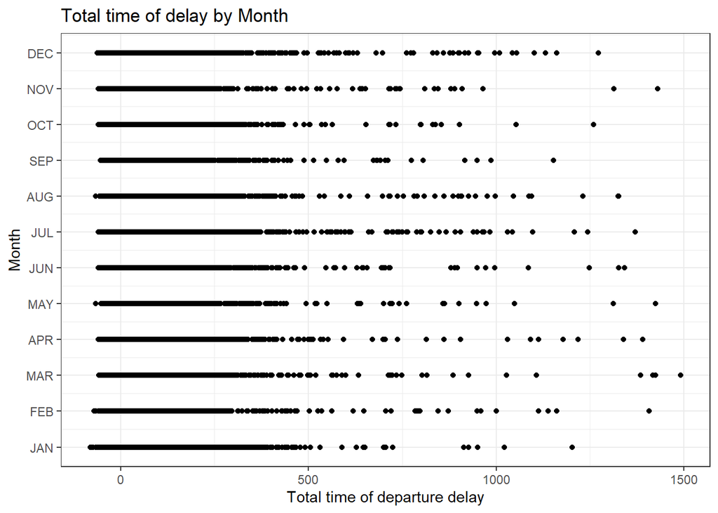

```r
ggplot(DENflights) + geom_point(aes(ARR_DELAY, MONTH)) +
  theme_bw() +
  scale_y_continuous(breaks = c(1, 2, 3, 4, 5, 6, 7, 8, 9, 10, 11, 12),
                     labels = c("JAN", "FEB", "MAR", "APR", "MAY", "JUN", "JUL", "AUG",
                                "SEP", "OCT", "NOV", "DEC"))+
  labs(title = 'Total time of delay by Month',
       x='Total time of departure delay',
       y='Month')
```

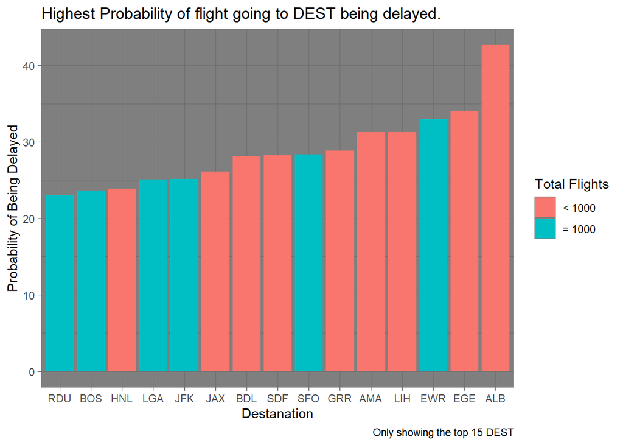

```r
ggplot(DEST_DEN_Delay, aes(x = DEST, y = prop_delay, fill = (sum_flights >= 1000))) +
  theme_dark() +
  geom_col() +
  labs(title = "Highest Probability of flight going to DEST being delayed.", x = "Destanation", y = "Probability of Being Delayed", caption = "Only showing the top 15 DEST") +
  scale_fill_discrete(name = "Total Flights", labels = c("< 1000", "≥ 1000"))
```

##These two graphs represent the reality of the question which is that the answer depends. The reason for a plane’s delay depends on its setting and the conditions that its setting put onto the plane. For example, a plane in upstate New York in January will have a much lower chance of arriving on time than a plane in Phoenix in October. The circumstances of a flight are the most defining factors for its chances of being delayed.

## Team Report

**Trent:** I created the graphs and found the probabilities for the amount of delays over 15 minutes by season and by airline carrier. I used the filter, group_by, summaries, and mutate functions to find the probabilities, and ggplot, specifically geometric point to graph the data.

**Logan:** I created the graphs and probailites of the flights going to DEN, and flights going from DEN, which DEST/ORIGIN will have the hightest propablitiy of being delyaed. I used fliter, summarise, arrange, slice, theme, scale, geom_col, labs (with caption) in my plots and to find the probabilities.

**Tyler**I created the graphs and found the probabilitys of all the flights that were delayed, how many of those are caused by the weather. As well as the plot for how air time affects the probability of being delayed. I used the mutate function to find if flights that were delayed if it was the weather, as well as to find the total amount of delayed flights in and out of denver. I used the filter function significantly to only use the flights that were delayed by weather and all the flights that were delayed. I grouped by carrier just have a variable that I could use to count everything under. I also created one of the team plots.

**Jack** I created the graphs and found the probabilities of flights based on whether there was a National Air System delay and whether there was a late aircraft delay. I used the filter and mutate functions to create my date for my graphs and find my probabilities, as well as the facet function to group my graphs into categories. I also added labels and a theme to my graph.